# Теплопроводность, детерминированное горение

Этап №1

Махорин И. С.

Российский университет дружбы народов, Москва, Россия

24 февраля 2024

# Информация

## Докладчики

- Махорин Иван Сергеевич
- Шаповалова Диана Дмитриевна
- Егорова Юлия Владимировна
- Павлова Варвара Юрьевна
- Лебединец Татьяна Александровна
- Великоднева Евгения Владимировна

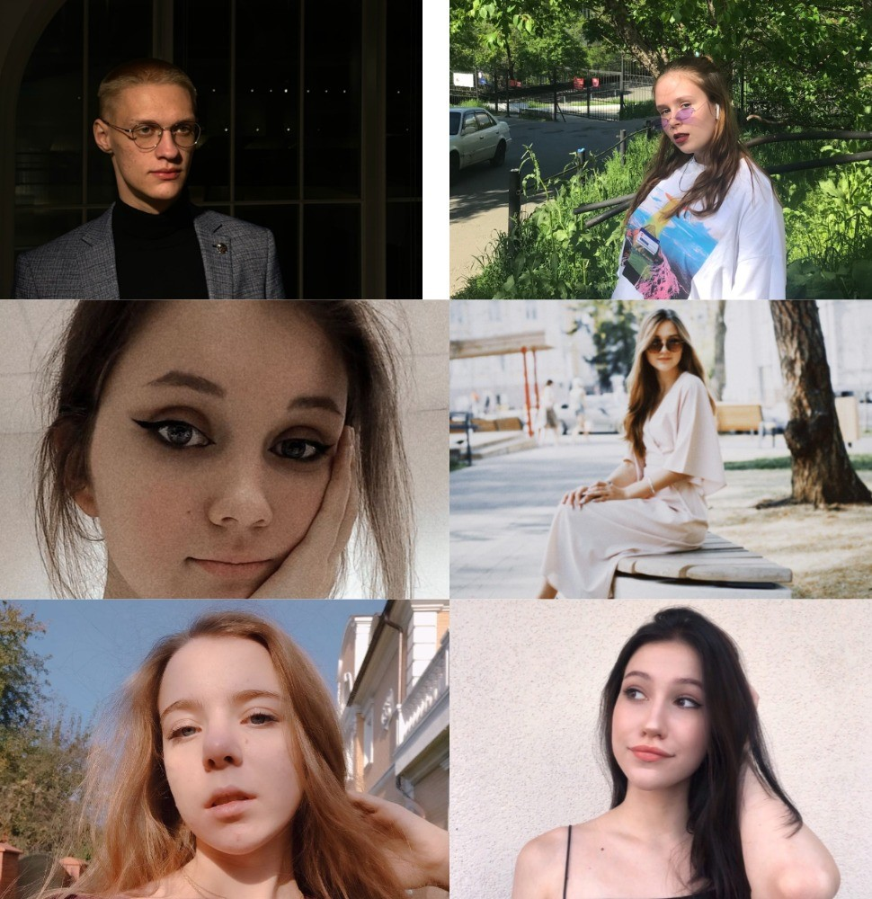

# Вводная часть

## Цели проекта

- Изучить методы математического моделирования на примере теплопроводности и детерминированного горения.

## Задачи проекта

- Исследовать влияние *E* на режим горения. При каком минимальном значении *E* возникает пульсирующий режим?
- Написать программу, решающую одномерное уравнение теплопроводности с адиабатическими граничными условиями, используя явную разностную схему. Исследовать поведение численного решения при различных значениях *χ*∆*t*/*h*2.
- Написать программу, решающую одномерное уравнение теплопроводности с адиабатическими граничными условиями, используя неявную разностную схему.

## Определение

- Горение представляет собой феномен природы, являющийся интересным объектом для научного исследования. Несмотря на комплексность и разнообразие физико-химических процессов, лежащих в его основе, многие из его характеристик могут быть описаны с использованием простых моделей. Для того чтобы произошло горение, необходимы определенные условия, такие как теплопроводность среды и возможность экзотермической реакции, скорость которой зависит от температуры.
- Детерминированное горение - это процесс горения, который подчиняется определенным законам физики и химии. В отличие от случайного горения, его характеристики можно предсказать с высокой точностью. Этот тип горения применяется, например, при моделировании работы двигателей внутреннего сгорания.

## Как протекает?

Обычное стационарное горение, при котором скорость распространения зоны активного горения или реакции (фронт пламени) не зависит от времени, может стать неустойчивым. Возникают быстрые периоды горения, сменяющиеся пассивными периодами.

В двумерном случае фронт горения может искривляться и состоять из нескольких зон активного горения, движущихся вдоль фронта и вглубь материала. Эти зоны могут взаимодействовать, периодически исчезать и появляться снова.

# Основная часть

## Размерная система уравнений

### Закон Аррениуса для реакции первого порядка

Вещество вида *A* переходит в *B*, при этом выделяется тепло. Для скорости *X**P* воспользуемся законом Аррениуса для реакции первого порядка:

$$\frac{\partial N}{\partial t} = -
\frac{N}{τ} e^{-E/RT}$$
(1.1)

- *N* — доля непрореагировавшего вещества *A*, меняющаяся от $1$ — исходное состояние, до $0$ — все прореагировало,
- *E* — энергия активации *X**P*
- *τ* — характерное время перераспределения энергии
- *T* — температура в данной точке

## Размерная система уравнений

### Одномерный случай

В одномерном случае необходимо добавить уравнение теплопроводности с дополнительным членом, отвечающим за энерговыделение:

$$ρc \frac{\partial T}{\partial t} = κ
\frac{\partial^2 T}{\partial x^2} - ρQ \frac{\partial N}{\partial
t}$$
(1.2)

- *ρ* — плотность
- *c* — удельная теплоемкость
- *κ* — коэффициент теплопроводности
- *Q* — удельное энерговыделение при *X**P*

## Размерная система уравнений

### Одномерный случай

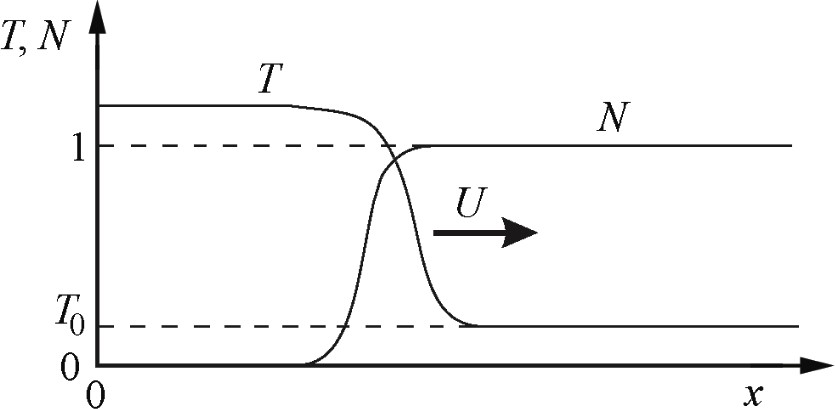

Профили температуры и исходного компонента в стационарной волне горения

## Система уравнений для безразмерных величин

Поделив уравнение теплопроводности на *ρ**Q* и перейдя к безразмерным температуре *T̃* = *c**T*/*Q* и энергии активации *Ẽ* = *c**E*/(*R**Q*) получим систему уравнений:

$$\frac{\partial T}{\partial t} = χ
\frac{\partial^2 T}{\partial x^2} - \frac{\partial N}{\partial
t}$$
(2.1)

- *χ* = *κ*/*ρ**c*
- *χ* - коэффициент температуропроводности

## Различные величины горения

### Одномерный случай

- Первый режим — скорость распространения волны постоянна, а профили температуры и концентрации переносятся вдоль оси *X* не деформируясь.
- Второй режим — скорость волны переменная, и горение распространяется в виде чередующихся вспышек и угасаний. От значения параметра *E*, зависит какой режим реализуется.

Существует критическое значение безразмерной энергии активации *E**. При *E* < *E** — стационарное горение, а при *E* > *E** — пульсирующее. Теоретически можно показать, что при *T*0 ≪ 1 критическое значение *E* * = 6, 56. При увеличении начальной температуры T0 критическое значение *E** возрастает.

## Различные режимы горения

### Двумерный случай

Для моделирования волны горения в двумерном случае в уравнение:

$$\frac{\partial T}{\partial t} = χ
\frac{\partial^2 T}{\partial x^2} - \frac{\partial N}{\partial
t}$$
(2.1)

нужно добавить перенос тепла по второй координате — $χ \frac{\partial^2 T}{\partial y^2}$

Кроме стационарного и пульсирующего режимов для этой двухмерной системы возможен третий режим распространения волны горения — спиновый.

## Различные режимы горения

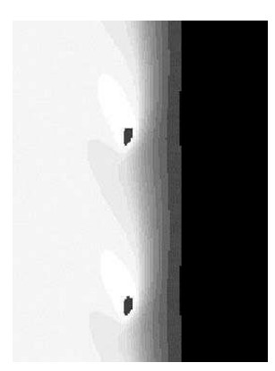

Характерный пример численного моделирования спинового режима горения

## Явная разностная схема

Рассмотрим численные методы решения одномерного уравнения теплопроводности без химических реакций:

$$\frac{\partial T}{\partial t} = χ
\frac{\partial^2 T}{\partial x^2}$$
(3.1)

Для этого в уравнении теплопроводности заменим частные производные на разностные:

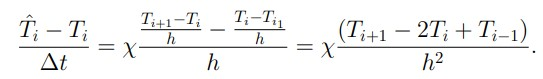

, (3.2)

## Явная разностная схема

Теперь учитываем *Х**Р*, добавим изменение безразмерной температуры за счёт энерговыделения в химических реакциях за шаг по времени:

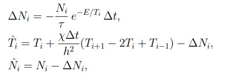

, (3.3)

*i* = 1, 2, ..., *n*

## Неявные разностные схемы

Неявная схема:

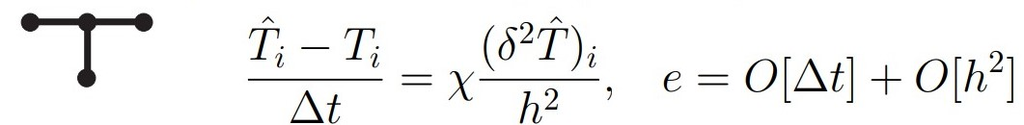

, (3.4)

Неявная схема Кранка-Николсон:

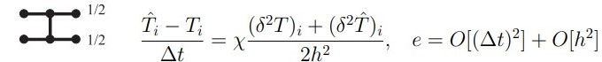

, (3.5)

## Неявные разностные схемы

Преобразовав выражение, получим следующую систему уравнений:

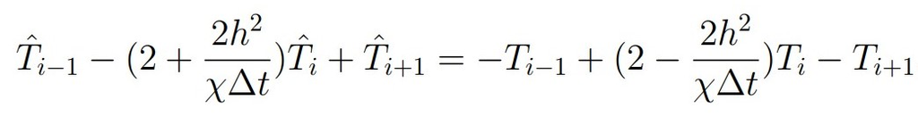

, (3.6)

# Заключительная часть

## Результаты

На данном этапе мы рассмотрели, что такое теплопроводность и детерминированное горение, что они из себя представляют и что в себе сочетают. Так же мы познакомились с основными понятиями, которые используются при изучении и построении уравнений и моделей теплопроводности и детерминированного горения.

## Источники

- Моделирование физических процессов и явлений на ПК / Д. А. Медведев, А. Л. Куперштох, Э. Р. Прууэл [и др.]. – Новосибирск : Новосиб. гос. ун-т, 2010. – 101 с. – ISBN 978-5-94356-933-3.